# Initial GTEX Analysis

David Gerard

2016-06-06

# Abstract

This is the same procedure as [here](http://dcgerard.github.io/succotash_sims/analysis/analyze_cleaned_gtex_muscle.html), but fitting RUVASH with a t-likelihood.

# Brief Summary

Read in the cleaned muscle gtex data and estimate the number of hidden confounders with `sva::num.sv()`.

```r
library(ggplot2)
load(file = "../output/cleaned_gtex_data/muscle.Rd")
k <- sva::num.sv(dat = muscle$Y, mod = muscle$X)
k
```

```
## [1] 32
```

$Y$ is log(COUNTS + 1) of the top 18636 expressed genes (genes with at least 10 reads per sample on average). Samples from the same individual were averaged, resulting in $n =$ 430. $X$ contains just an intercept and an indicator for gender. The idea here is that genes on sex chromosomes are “positive controls,” so the best method will be that which has the most genes on sex chromosomes among the most significant genes. This is the setup that Gagnon-Bartsch and Speed (2012) and Wang et al. (2015) use to evaluate performance between these confounder adjustment methods.

Control genes are the housekeeping genes identified by Eisenberg and Levanon (2013). This is a different list than that used by Gagnon-Bartsch and Speed (2012), which was drawn from Eisenberg and Levanon (2003). In total, there are 3609 housekeeping genes among the 18636 most expressed genes in the GTEX muscle data.

# Analysis

The results are almost the exact same as in the normal case. This makes sense since I used a degrees of freedom of 396 ($n - k - q$). The only difference is that slightly more genes are called significant when using the t.

## RUVASH vs RUV4

Now fit RUVASH and RUV4.

```r
qthresh <- 0.05
onsex <- muscle$chrom == "X" | muscle$chrom == "Y"
ruvash_out <- ashr::ash_ruv(Y = t(muscle$Y), X = muscle$X, ctl = muscle$ctl, k = k,
                            likelihood = "t", posthoc_inflate = FALSE)
```

```
## Warning in genhypergeo_series(U, L, z, tol = tol, maxiter = maxiter,
## check_mod = check_mod, : series not converged

## Warning in genhypergeo_series(U, L, z, tol = tol, maxiter = maxiter,
## check_mod = check_mod, : series not converged
```

```
## Warning in sqrt(postmean2(m, betahat, sebetahat, v) - postmean(m,
## betahat, : NaNs produced
```

```r
ruvash_onsex <- onsex[order(ruvash_out$lfdr)]
ruv4_out <- ruv::RUV4(Y = t(muscle$Y), X = muscle$X[, 2, drop = FALSE], ctl = muscle$ctl, k = k)
ruv4_onsex <- onsex[order(ruv4_out$p)]
num_sig <- sum(ruvash_out$qvalue < qthresh)
qout <- qvalue::qvalue(p = ruv4_out$p)
num_sig_ruv4 <- sum(qout$qvalue < qthresh)
```

The warnings are from the call to `ashr`. I get a lot of warnings when using the t-likelihood. It is also a lot slower than the normal likelihood.

The orderings that RUVASH and RUV4 give for the most significant genes are very similar. RUVASH says that 177 genes have a q-value less than 0.05. RUVASH says that 59 of the top 177 genes are on a sex chromosome while RUV4 says that 57 of the top 177 genes are on a sex chromosome. We can calculate the Kendall’s tau of the rankings that RUV4 and RUVASH give for the top 177 genes:

```r
lfdr_order <- order(ruvash_out$lfdr)
tau <- cor(c(ruv4_out$p)[lfdr_order[1:num_sig]], ruvash_out$lfdr[lfdr_order[1:num_sig]], method = "kendall")
tau
```

```
## [1] 0.8634
```

Their rankings don’t differ that much in the first 177 genes. The ordering later on gets a very different.

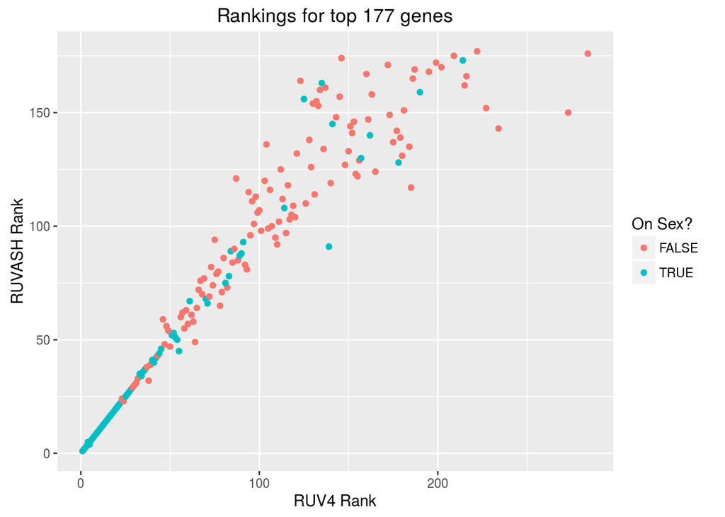

```r
qplot(rank(c(ruv4_out$p))[lfdr_order[1:num_sig]], rank(ruvash_out$lfdr)[lfdr_order[1:num_sig]],
      xlab = "RUV4 Rank", ylab = "RUVASH Rank",
      main = paste("Rankings for top", num_sig, "genes"),
      color = onsex[lfdr_order[1:num_sig]]) +
    guides(color=guide_legend(title="On Sex?"))
```

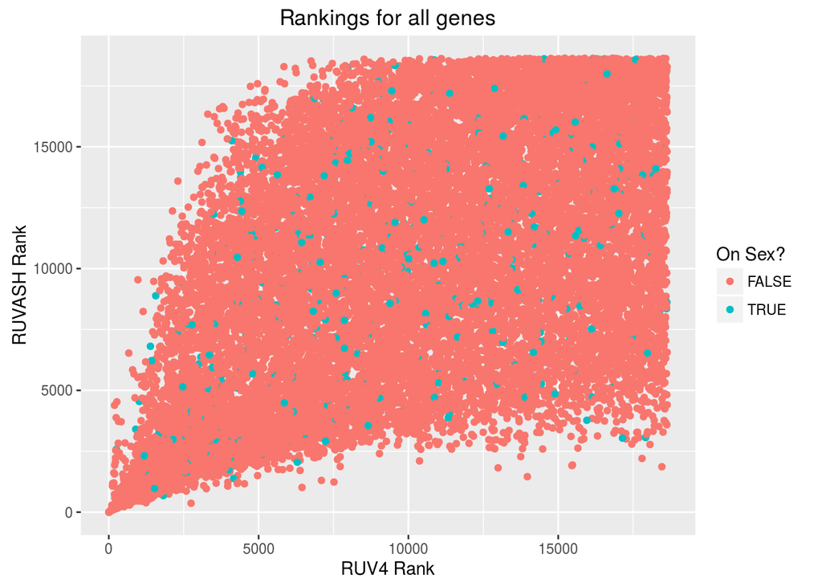

```r
qplot(rank(c(ruv4_out$p)), rank(ruvash_out$lfdr),
      xlab = "RUV4 Rank", ylab = "RUVASH Rank",
      main = "Rankings for all genes",
      color = onsex[lfdr_order]) +
    guides(color=guide_legend(title="On Sex?"))
```

However, I am going to argue that RUVASH is much better calibrated than RUV4. RUV4, followed by using `qvalue` (Storey 2003), estimates $\pi_0$ to be 0.6636 against RUVASH’s estimated $\pi_0$ of 0.9691. I think RUVASH’s estimate is much more realistic in this scenario as 0.9664 of the genes are not on a sex chromosome, so one would think that $\pi_0$ is closer to this value. Furthermore, RUV4 + `qvalue` says that 2046 genes have a q-value less than 0.05, compared to RUVASH’s estimate of 177. The proportion of the top 177 RUVASH genes on a sex chromosome is 0.3333. The proportion of the top 2046 RUV4 genes on a sex chromosome is 0.0694, which seems like very poor performance.

The shift from sex chromosome genes to non-sex chromosome genes is not as clear as in the heart data set.

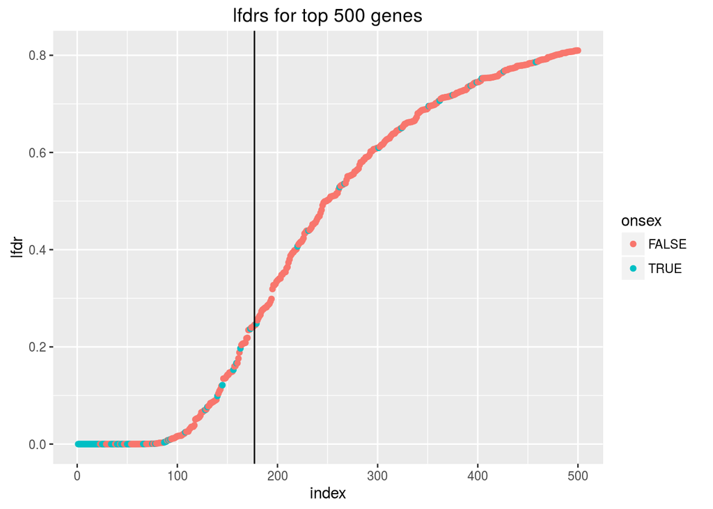

```r
num_plot <- 500
df_lfdr <- data.frame(lfdr = ruvash_out$lfdr[lfdr_order][1:num_plot],
                      qvalue = ruvash_out$qvalue[lfdr_order][1:num_plot],
                      onsex = ruvash_onsex[1:num_plot],
                      index = 1:num_plot)
ggplot(data = df_lfdr, mapping = aes(y = lfdr, x = index, color = onsex)) + geom_point() +
    geom_vline(xintercept = num_sig) +
    ggtitle(paste("lfdrs for top", num_plot, "genes"))
```

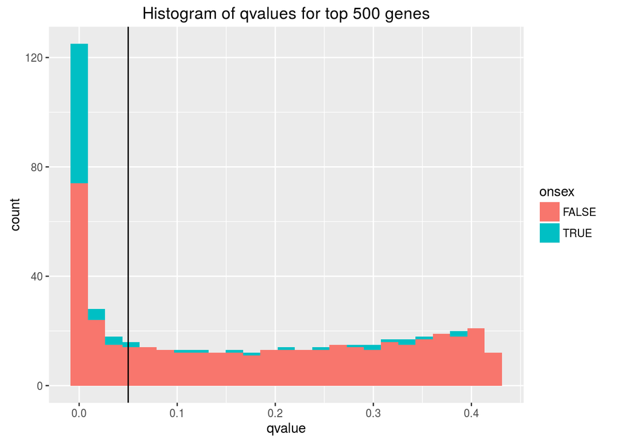

```r
ggplot(data = df_lfdr, mapping = aes(x = qvalue, fill = onsex)) + geom_histogram(bins = 25) +
    geom_vline(xintercept = qthresh) +
    ggtitle(paste("Histogram of qvalues for top", num_plot, "genes"))
```

RUV4 is not having a problem with the p-value distribution. Indeed, it looks pretty good:

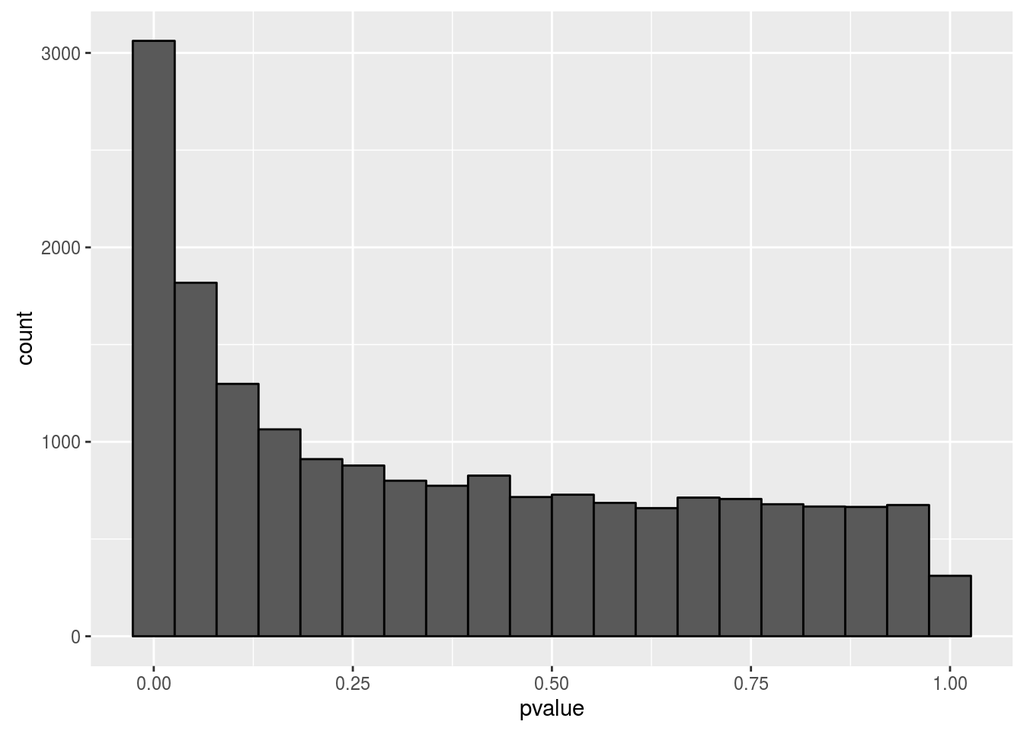

```r
ggplot(data = data.frame(pvalue = c(ruv4_out$p)), aes(x = pvalue, color = I("black"))) +
    geom_histogram(, bins = 20)
```

The t-statistics for the genes that RUVASH says is null match up ok against a standard normal.

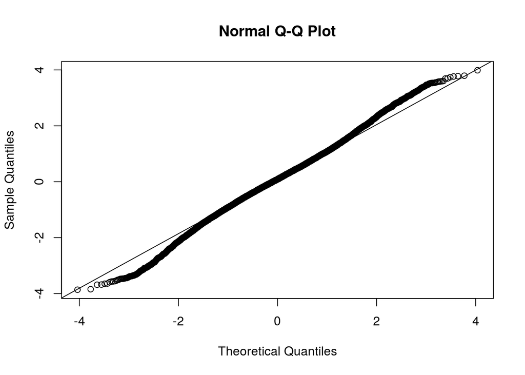

```r
sig_genes <- ruvash_out$qvalue < 0.05
tstat <- ruvash_out$ruv$betahat / ruvash_out$ruv$sebetahat
qqnorm(tstat[!sig_genes])
qqline(tstat[!sig_genes])
```

# Use inflation adjusted p-values in q-value

We can insert the p-values from the variance inflated t-statistics into `qvalue` and see if its calibration is any better.

```r
posthoc_mult <- ncol(muscle$Y) / (ncol(muscle$Y) - ncol(muscle$X) - k)
pvalue_noinflate <- 2 * pt(-abs(ruvash_out$ruv$t * sqrt(posthoc_mult)),
                             df = ncol(muscle$Y) - ncol(muscle$X) - k)
qout_adjust <- qvalue::qvalue(p = pvalue_noinflate)
num_sig_ruv4_adjust <- sum(qout_adjust$qvalue < qthresh)
```

`qvalue` estimates that the proportion of null genes is now 1, with 262 genes now having a q-value below 0.05. The histogram of p-values is

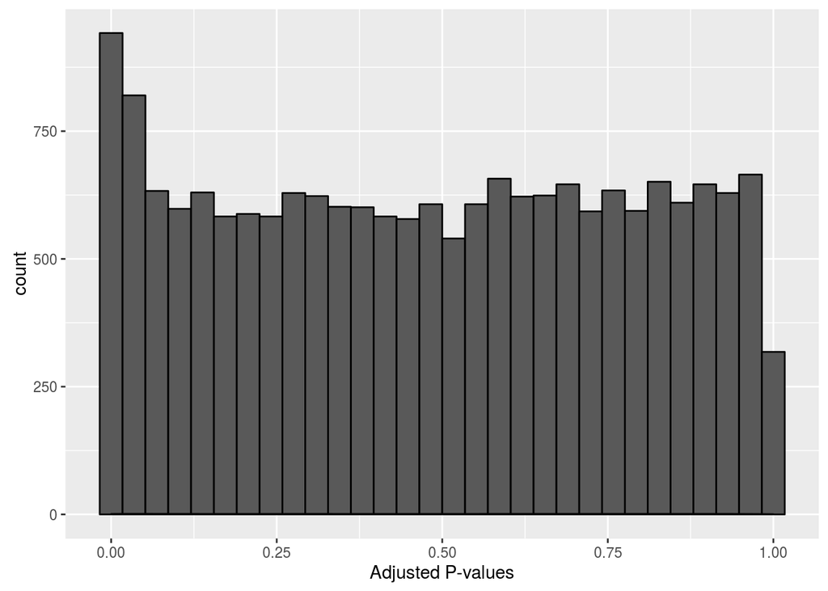

```r
qplot(pvalue_noinflate, color = I("black"), bins = 30, xlab = "Adjusted P-values") +
    geom_density()
```

# References

Eisenberg, Eli, and Erez Y Levanon. 2003. “Human Housekeeping Genes Are Compact.” *TRENDS in Genetics* 19 (7). Elsevier: 362–65.

———. 2013. “Human Housekeeping Genes, Revisited.” *Trends in Genetics* 29 (10). Elsevier: 569–74.

Gagnon-Bartsch, Johann A, and Terence P Speed. 2012. “Using Control Genes to Correct for Unwanted Variation in Microarray Data.” *Biostatistics* 13 (3). Biometrika Trust: 539–52.

Storey, John D. 2003. “The Positive False Discovery Rate: A Bayesian Interpretation and the Q-Value.” *Annals of Statistics*. JSTOR, 2013–35.

Wang, Jingshu, Qingyuan Zhao, Trevor Hastie, and Art B Owen. 2015. “Confounder Adjustment in Multiple Hypotheses Testing.” *ArXiv Preprint ArXiv:1508.04178*.